# Лабораторная работа № 7

Управление журналами событий в системе

Жукова С. В. НПИбд-01-24

Российский университет дружбы народов, Москва, Россия

18 октярбря 2025

## Докладчик

- Жукова София Викторовна
- студентка
- направления прикладной информатика
- Российский университет дружбы народов
- 1032240966@pfur.ru
- https://svzhukova.github.io/ru/

# Вводная часть

Лабораторная работа Управление журналами событий в системе

## Цель

Получить навыки работы с журналами мониторинга различных событий в системе.

## Выполнение лабораторной работы

## Мониторинг журнала системных событий в реальном времени

Запустим три вкладки терминала и в каждом из них получите полномочия администратора

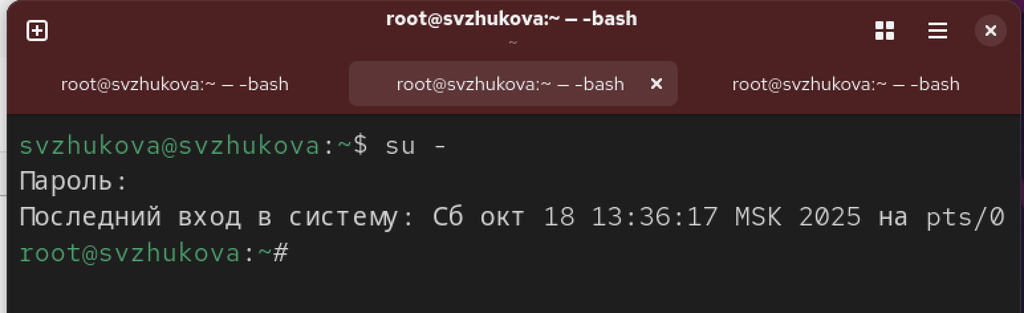

3 Вкладки

## На второй вкладке терминала запустите мониторинг системных событий в реальном времени

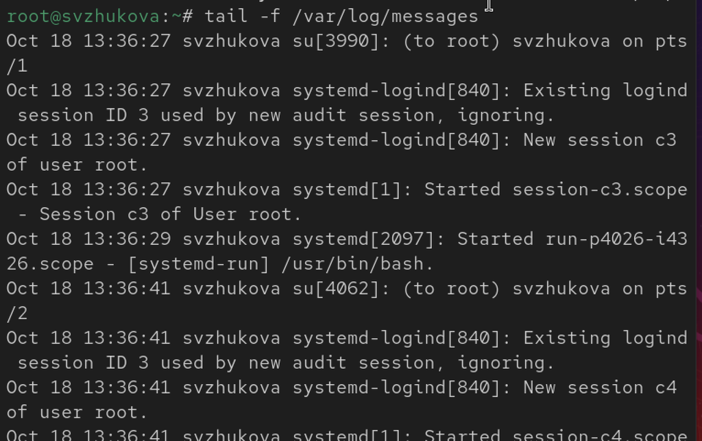

Мониторинг системных событий в реальном времени

## В третьей вкладке терминала вернемся к учётной записи своего пользователя

и попробуем получить полномочия администратора, но введем неправильный пароль. Обратим внимание, что во второй вкладке терминала с мониторингом событий появится сообщение «FAILED SU (to root) username …». Отображаемые на экране сообщения также фиксируются в файле /var/log/messages

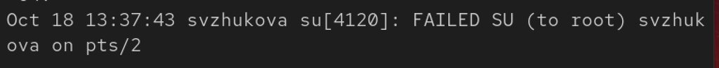

FAILED SU (to root) username …

## В третьей вкладке терминала из оболочки пользователя введем

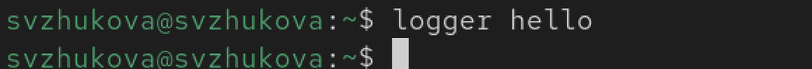

logger hello

## Во второй вкладке терминала с мониторингом событий мы увидим сообщение, которое также будет зафиксировано в файле /var/log/messages

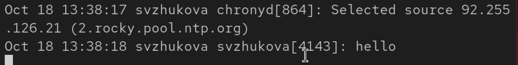

hello

## Во второй вкладке терминала с мониторингом остановим трассировку файла сообщений мониторинга реального времени, используя Ctrl + c . Затем запустим мониторинг сообщений безопасности (последние 20 строк соответствующего файла логов):

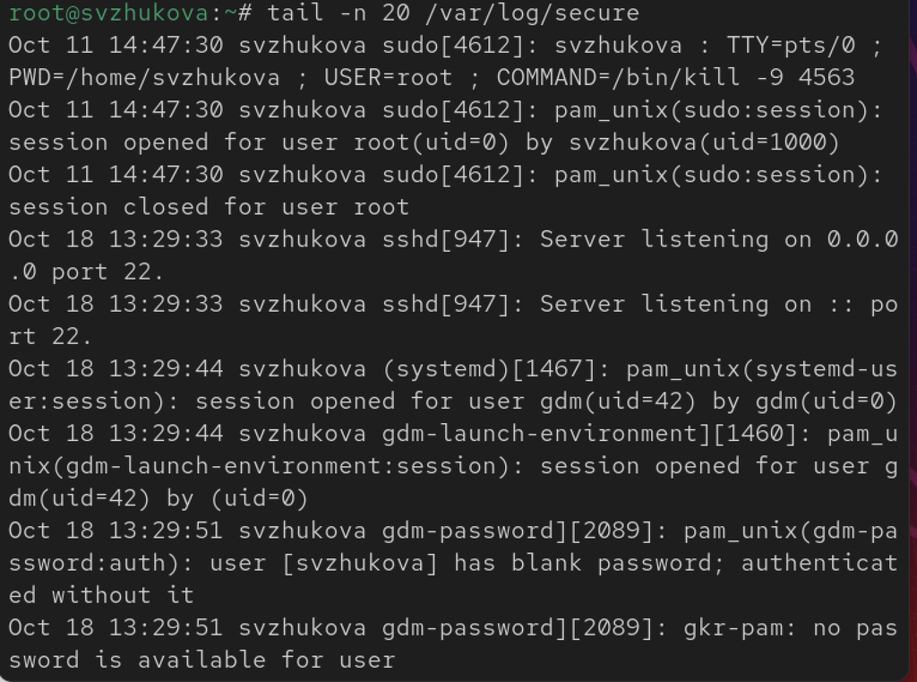

## Изменение правил rsyslog.conf

По умолчанию веб-служба не регистрирует свои сообщения через rsyslog, а пишет свой собственный журнал (в каталоге /var/log/httpd). Настроим регистрацию сообщений веб-службы через syslog, создав правило, регистрирующее отладочные сообщения в отдельном лог-файле. Для этого выполним следующие действия.

В первой вкладке терминала установите Apache

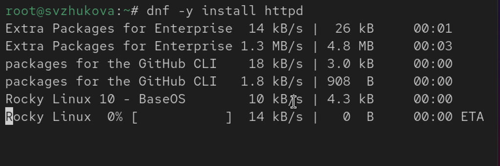

Установим Apache

## После окончания процесса установки запустим веб-службу

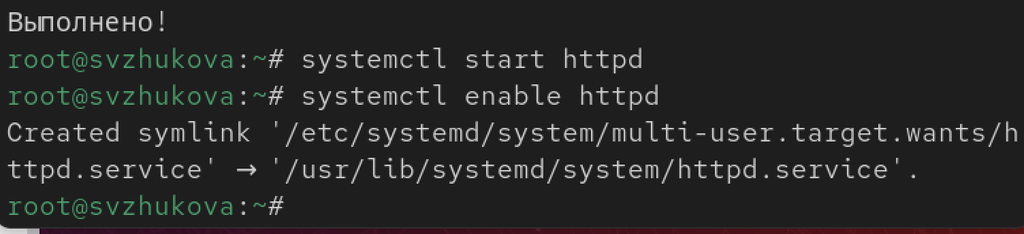

Запустим

## Во второй вкладке терминала посмотрим журнал сообщений об ошибках веб-службы

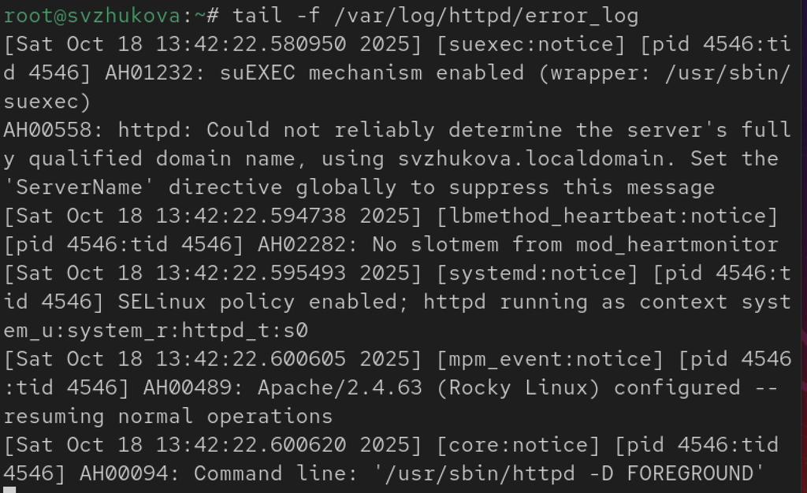

Журнал сообщений об ошибках веб-служб

## В третьей вкладке терминала получим полномочия администратора и в файле конфигурации /etc/httpd/conf/httpd.conf в конце добавим следующую строку

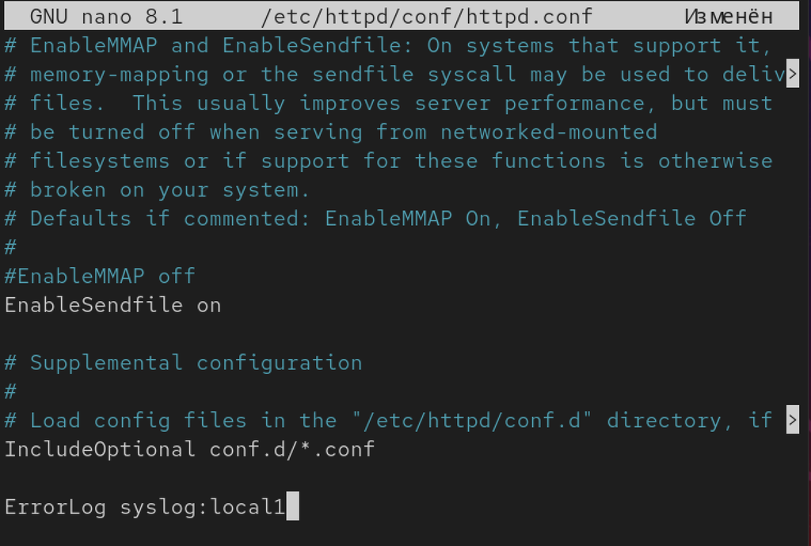

ErrorLog syslog:local1

## В каталоге /etc/rsyslog.d создалим файл мониторинга событий веб-службы

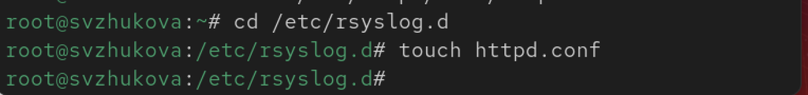

Файл мониторинга событий веб-службы

## Открыв его на редактирование, пропишим в нём

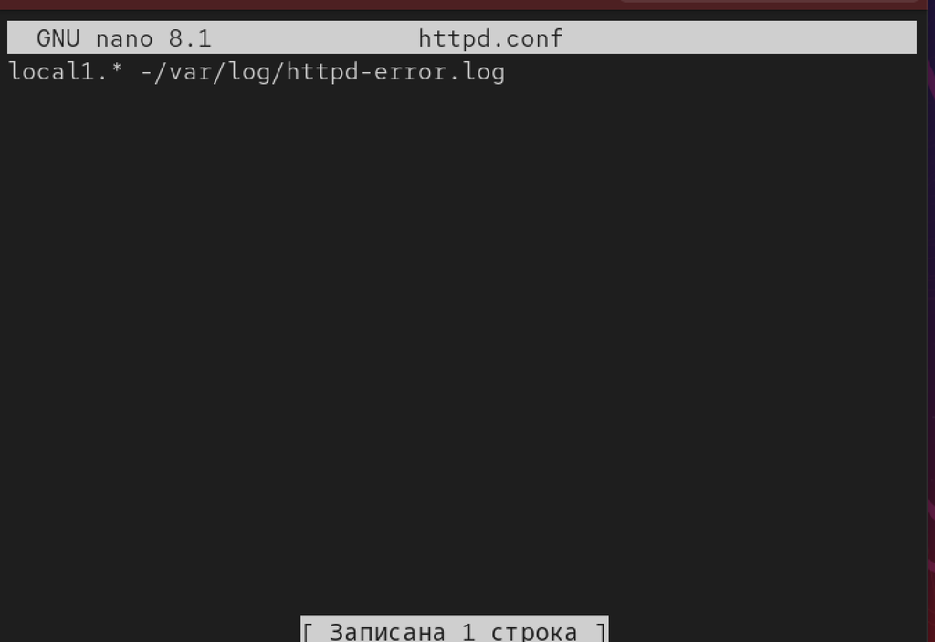

nano

## Перейдем в первую вкладку терминала и перезагрузите конфигурацию rsyslogd и веб-службу

Все сообщения об ошибках веб-службы теперь будут записаны в файл /var/log/httpd-error.log, что можно наблюдать или в режиме реального времени, используя команду tail с соответствующими параметрами, или непосредственно просматривая указанный файл.

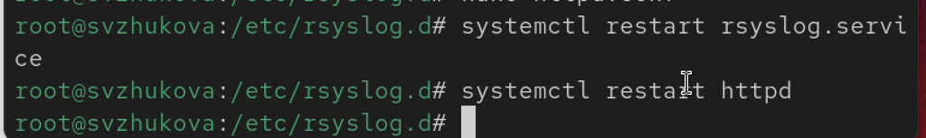

rsyslogd

## В третьей вкладке терминала создайте отдельный файл конфигурации для мониторинга отладочной информации

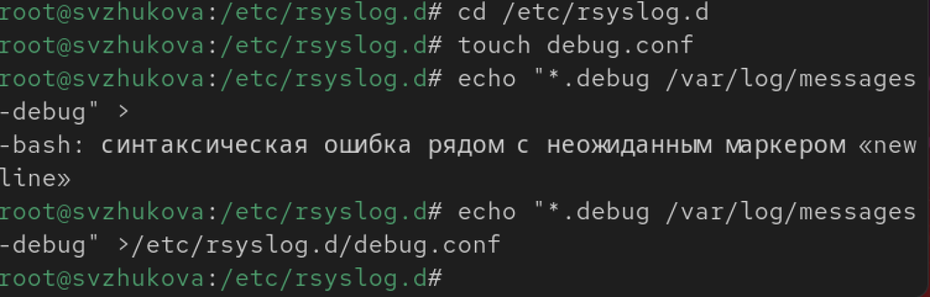

Мониторинг отладочной информации

## В первой вкладке терминала снова перезапустим rsyslogd

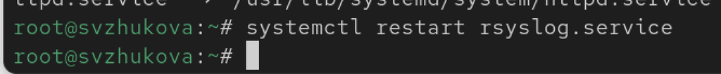

Перезапустим

## Во второй вкладке терминала запустим мониторинг отладочной информации:

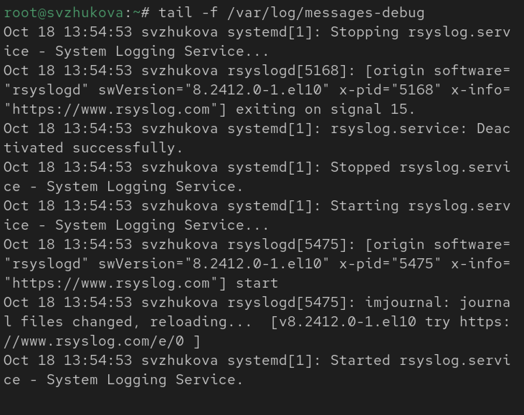

Мониторинг отладочной информаци

## В третьей вкладке терминала введем

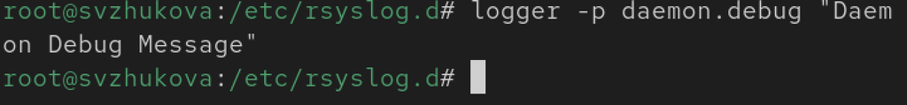

logger -p daemon.debug “Daemon Debug Message”

В терминале с мониторингом посмотрим сообщение отладки

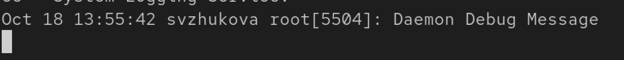

Посмотрим

## Использование journalctl

Во второй вкладке терминала посмотрии содержимое журнала с событиями с момента последнего запуска системы

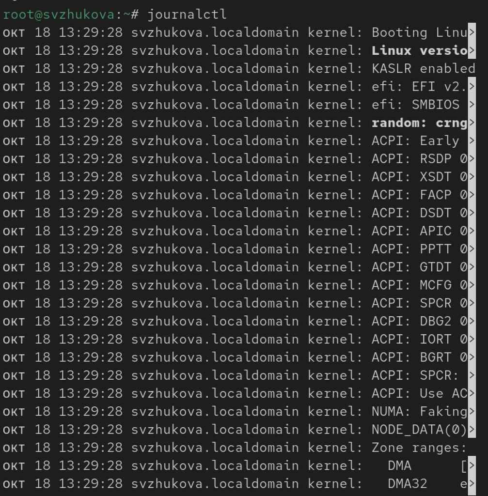

Содержимое журнала с событиями

## Просмотр содержимого журнала без использования пейджера

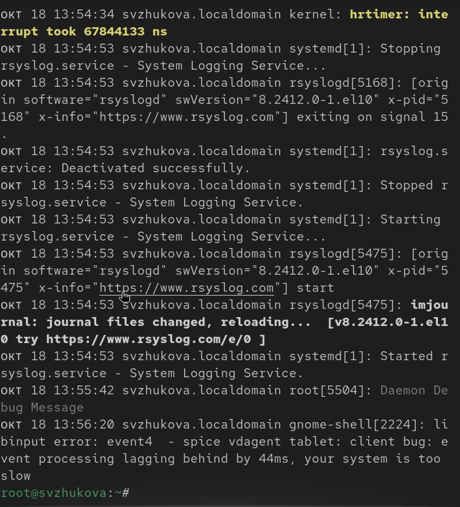

Без использования пейджера

## Режим просмотра журнала в реальном времени:

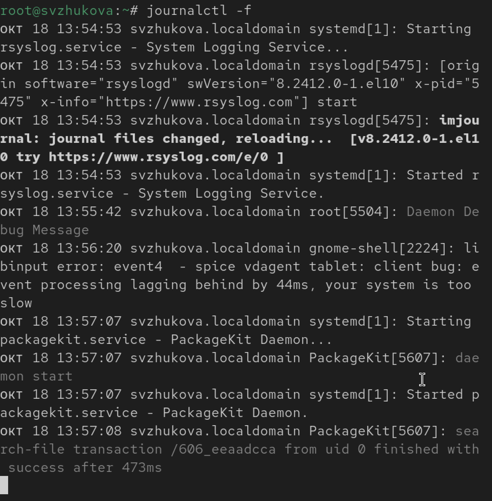

В в реальном времени

## Для использования фильтрации просмотра конкретных параметров журнала введем journalctl и дважды нажмем клавишу Tab

[figure not shown]

## Просмотрим события для UID0:

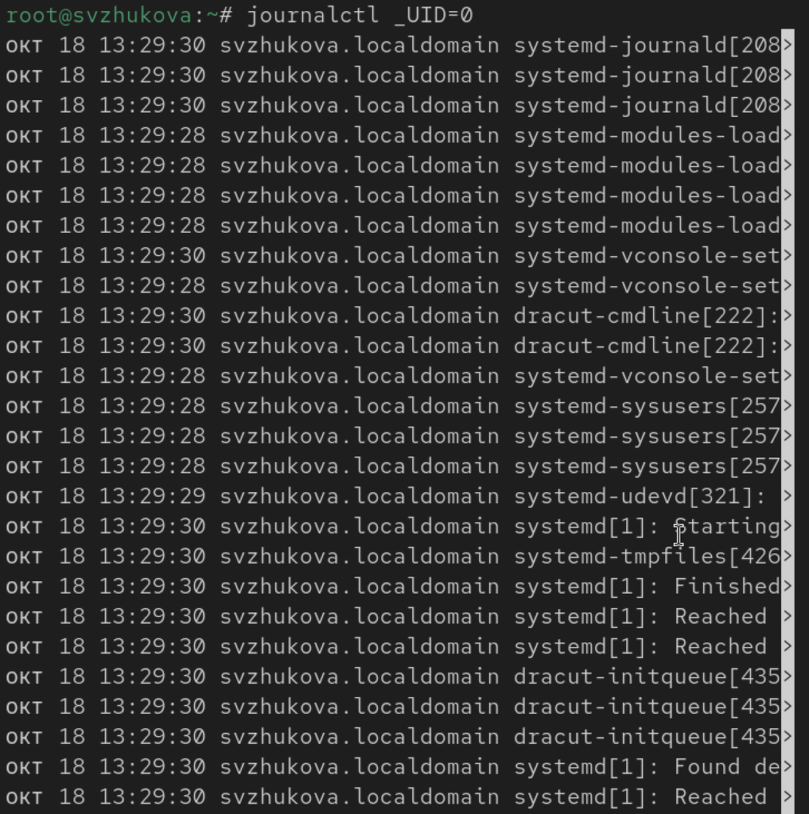

UID0

## Для отображения последних 20 строк журнала введем

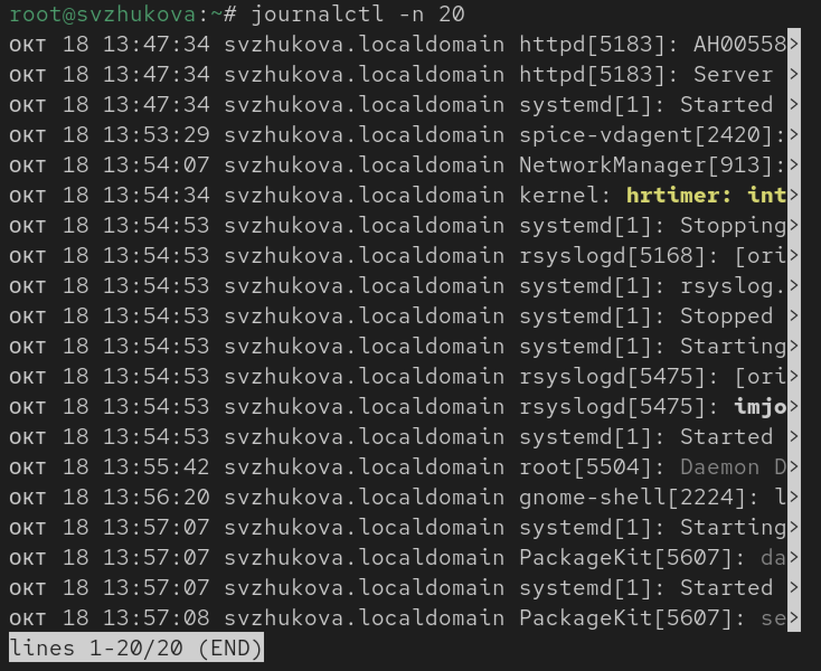

Последние 20 строк

## Для просмотра только сообщений об ошибках введем

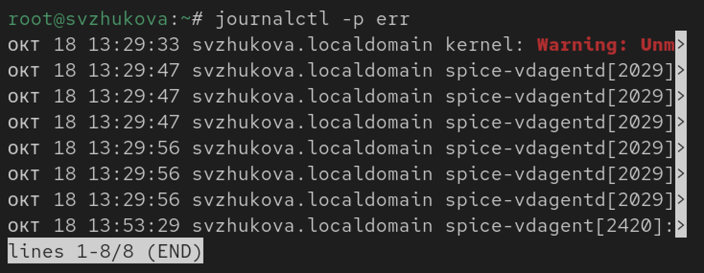

Сообщения об ошибках

## Чтобы просмотреть сообщения журнала, записанные за определённый период времени, мы можем использовать параметры –since и –until. Обе опции принимают параметр времени в формате YYYY-MM-DD hh:mm:ss

Кроме того, мы можем использовать yesterday, today и tomorrow в качестве параметров. Например, для просмотра всех сообщений со вчерашнего дня введем

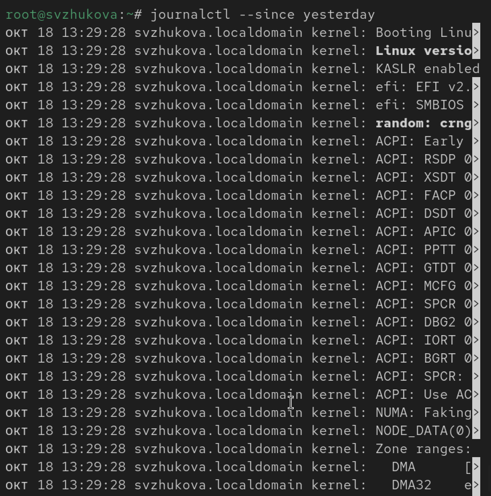

yesterday

## Показать все сообщения с ошибкой приоритета, которые были зафиксированы со вчерашнего дня

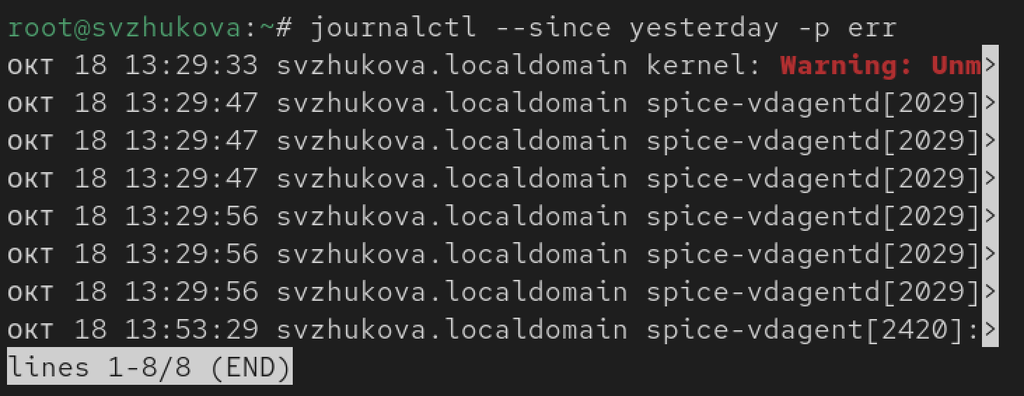

Сообщения с ошибкой приоритета

## Если нам нужна детальная информация, то используем

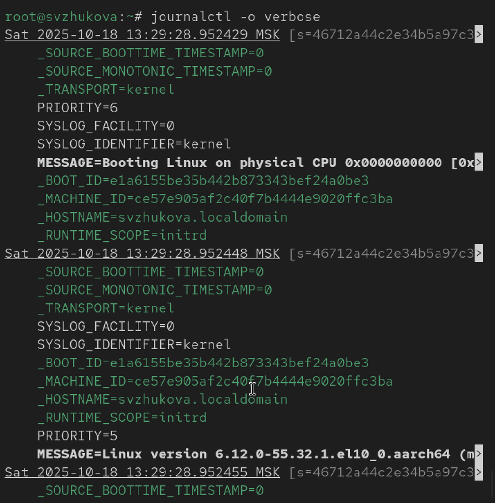

Детальная информация

## Для просмотра дополнительной информации о модуле sshd введем

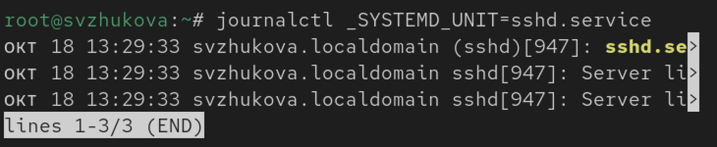

Введем